# Assignment 8 - Working With Textual Data

Ken Benoit and Slava Mikhaylov

### Exercise summary

This exercise is designed to get you working with quanteda. The focus will be on exploring the package and getting some texts into the **corpus** object format. quanteda package has several functions for creating a corpus of texts which we will use in this exercise.

1. Getting Started.

   You will first need to install the package:

   ```r
   install.packages("quanteda")
   ```

2. Exploring **quanteda** functions.

   Look at the Quick Start vignette, and browse the manual for quanteda. You can use `example()` function for any function in the package, to run the examples and see how the function works. Of course you should also browse the documentation, especially `?corpus` to see the structure and operations of how to construct a corpus. The website http://quanteda.io has extensive documentation.
3. Making a corpus and corpus structure
   1. From a vector of texts already in memory.

      The simplest way to create a corpus is to use a vector of texts already present in R’s global environment. Some text and corpus objects are built into the package, for example `data_char_ukimmig2010` is the UTF-8 encoded set of 9 UK party manifesto sections from 2010, that deal with immigration policy. addresses. Try using `corpus()` on this set of texts to create a corpus.

      Once you have constructed this corpus, use the `summary()` method to see a brief description of the corpus. The names of the corpus `data_char_ukimmig2010` should have become the document names.
   2. From a directory of text files.

      The `readtext()` function from the **readtext** package can read (almost) any set of files into an object that you can then call the `corpus()` function on, to create a corpus. (See `?readtext` for an example.)

      Here you are encouraged to select any directory of plain text files of your own.  
      How did it work? Try using `docvars()` to assign a set of document-level variables. If you do not have a set of text files to work with, then you can use the UK 2010 manifesto texts on immigration, in the Day 8 folder, like this:

      ```
      ## quanteda version 0.99
      ```

      ```
      ## Using 2 of 4 threads for parallel computing
      ```

      ```r
      require(quanteda)
      manfiles <- readtext("https://github.com/kbenoit/ME114/raw/master/day8/UKimmigTexts.zip")
      mycorpus <- corpus(manfiles)
      ```

   3. From `.csv` or `.json` files — see the documentation for the package `readtext` (`help(package = "readtext")`).

      Here you can try one of your own examples, or just file this in your mental catalogue for future reference.
4. Explore some phrases in the text.

   You can do this using the `kwic` (for “key-words-in-context”) to explore a specific word or phrase.

   ```r
   kwic(data_corpus_inaugural, "terror", 3)
   ```

   ```
   ##
   ##     [1797-Adams, 1325]             violence, by | terror |
   ##  [1933-Roosevelt, 112] unreasoning, unjustified | terror |
   ##  [1941-Roosevelt, 287]          by a fatalistic | terror |
   ##    [1961-Kennedy, 866]     uncertain balance of | terror |
   ##     [1981-Reagan, 813]       Americans from the | terror |
   ##   [1997-Clinton, 1055]        the fanaticism of | terror |
   ##   [1997-Clinton, 1655]   strong defense against | terror |
   ##     [2009-Obama, 1632]         aims by inducing | terror |
   ##
   ##  , intrigue,
   ##  which paralyzes needed
   ##  , we proved
   ##  that stays the
   ##  of runaway living
   ##  . And they
   ##  and destruction.
   ##  and slaughtering innocents
   ```

   Try substituting your own search terms, or working with your own corpus.
5. Create a document-feature matrix, using `dfm`. First, read the documentation using `?dfm` to see the available options.

   ```r
   mydfm <- dfm(data_corpus_inaugural, remove = stopwords("english"))
   mydfm
   ```

   ```
   ## Document-feature matrix of: 58 documents, 9,221 features (92.6% sparse).
   ```

   ```r
   topfeatures(mydfm, 20)
   ```

   ```
   ##          ,          .          -     people          ; government
   ##       7026       4945        762        575        565        564
   ##         us        can       upon       must      great        may
   ##        478        471        371        366        340        338
   ##     states      shall      world    country      every     nation
   ##        333        314        311        304        298        293
   ##      peace        one
   ##        254        252
   ```

   Experiment with different `dfm` options, such as `stem = TRUE`. The function `dfm_trim()` allows you to reduce the size of the dfm following its construction.

   Grouping on a variable is an excellent feature of `dfm()`, in fact one of my favorites.  
   For instance, if you want to aggregate all speeches by presidential name, you can execute

   ```r
   mydfm <- dfm(data_corpus_inaugural, groups = "President")
   mydfm
   ```

   ```
   ## Document-feature matrix of: 35 documents, 9,357 features (88.3% sparse).
   ```

   ```r
   docnames(mydfm)
   ```

   ```
   ##  [1] "Washington" "Adams"      "Jefferson"  "Madison"    "Monroe"
   ##  [6] "Jackson"    "Van Buren"  "Harrison"   "Polk"       "Taylor"
   ## [11] "Pierce"     "Buchanan"   "Lincoln"    "Grant"      "Hayes"
   ## [16] "Garfield"   "Cleveland"  "McKinley"   "Roosevelt"  "Taft"
   ## [21] "Wilson"     "Harding"    "Coolidge"   "Hoover"     "Truman"
   ## [26] "Eisenhower" "Kennedy"    "Johnson"    "Nixon"      "Carter"
   ## [31] "Reagan"     "Bush"       "Clinton"    "Obama"      "Trump"
   ```

   Note that this groups Theodore and Franklin D. Roosevelt together – to separate them we would have needed to add a firstname variable using `docvars()` and grouped on that as well.

   Do this to aggregate the Irish budget corpus (`data_corpus_irishbudget2010`) by political party, when creating a dfm.
6. Explore the ability to subset a corpus.

   There is a `corpus_subset()` method defined for a corpus, which works just like R’s normal `subset()` command. For instance if you want a wordcloud of just Obama’s two inagural addresses, you would need to subset the corpus first:

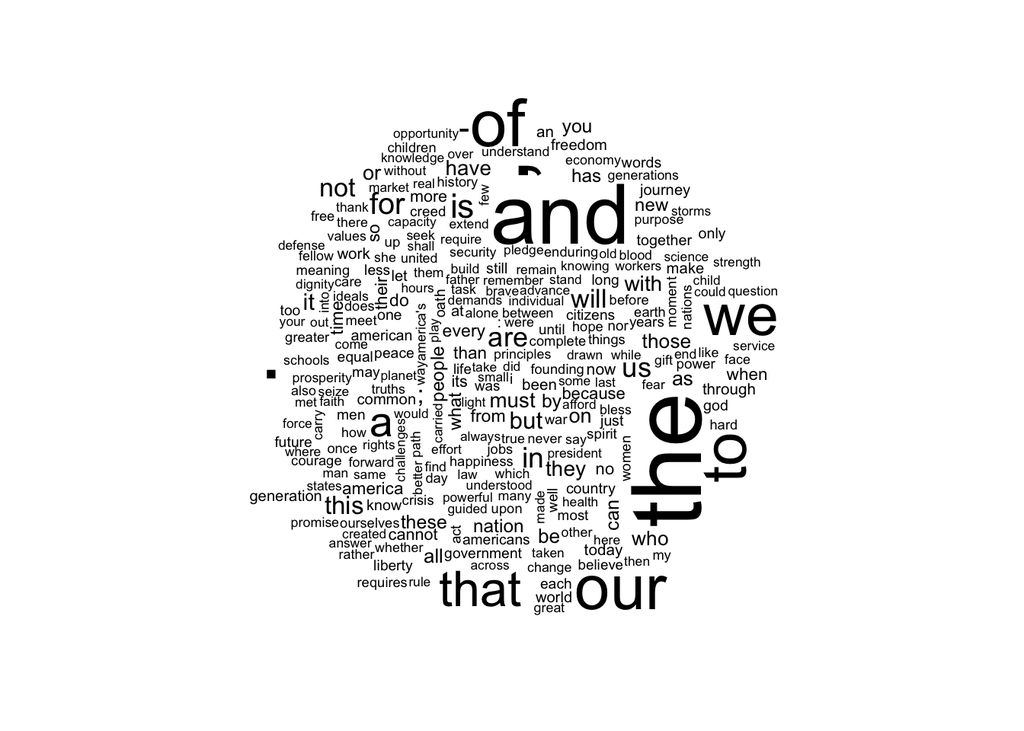

   ```r
   obamadfm <- dfm(corpus_subset(data_corpus_inaugural, President=="Obama"))
   textplot_wordcloud(obamadfm)
   ```

   Try producing that plot without the stopwords. See `dfm_remove()` to remove stopwords from the dfm object directly, or supply the `remove` argument to `dfm()`.
7. **Preparing and pre-processing texts**
   1. “Cleaning”" texts

      It is common to “clean” texts before processing, usually by removing punctuation, digits, and converting to lower case. Look at the documentation for `char_tolower()` and use the command on the `data_char_sampletext` text (you can load this from **quantedaData** using `data(data_char_sampletext)`. Can you think of cases where cleaning could introduce homonymy?
   2. Tokenizing texts

      In order to count word frequencies, we first need to split the text into words through a process known as *tokenization*. Look at the documentation for **quanteda**’s `tokens()` function. Use the `tokens` command on `data_char_sampletext`, and examine the results. Are there cases where it is unclear where the boundary between two words lies? You can experiment with the options to `tokens`.

      Try tokenizing the sentences from `data_char_sampletext` into sentences, using `tokens(x, what = "sentence")`.
   3. Stemming.

      Stemming removes the suffixes using the Porter stemmer, found in the **SnowballC** library. The **quanteda** function* to invoke the stemmer end with `*_wordstem`. Apply stemming to the `data_char_sampletext` (using `char_wordstem()`) and examine the results. Why does it not appear to work, and what do you need to do to make it work? How would you apply this to the sentence-segmented vector?
   4. Applying “pre-processing” to the creation of a `dfm`.

      **quanteda**’s `dfm()` function makes it wasy to pass the cleaning arguments to clean, which are executed as part of the tokenization implemented by `dfm()`. Compare the steps required in a similar text preparation package, [**tm**](http://cran.r-project.org/package=tm):

      ```r
      require(tm)
      data("crude")
      crude <- tm_map(crude, content_transformer(tolower))
      crude <- tm_map(crude, removePunctuation)
      crude <- tm_map(crude, removeNumbers)
      crude <- tm_map(crude, stemDocument)
      tdm <- TermDocumentMatrix(crude)

      # same in quanteda
      require(quanteda)
      crudeCorpus <- corpus(crude)
      crudeDfm <- dfm(crudeCorpus)
      ```

      Inspect the dimensions of the resulting objects, including the names of the words extracted as features. It is also worth comparing the structure of the document-feature matrixes returned by each package. **tm** uses the [slam](http://cran.r-project.org/web/packages/slam/index.html) *simple triplet matrix* format for representing a [sparse matrix](http://en.wikipedia.org/wiki/Sparse_matrix).

      It is also – in fact almost always – useful to inspect the structure of this object:

      ```r
      str(tdm)
      ```

      ```
      ## List of 6
      ##  $ i       : int [1:1877] 42 77 100 136 148 158 163 164 174 180 ...
      ##  $ j       : int [1:1877] 1 1 1 1 1 1 1 1 1 1 ...
      ##  $ v       : num [1:1877] 1 2 1 1 2 2 1 1 2 2 ...
      ##  $ nrow    : int 848
      ##  $ ncol    : int 20
      ##  $ dimnames:List of 2
      ##   ..$ Terms: chr [1:848] "abdulaziz" "abil" "abl" "about" ...
      ##   ..$ Docs : chr [1:20] "127" "144" "191" "194" ...
      ##  - attr(*, "class")= chr [1:2] "TermDocumentMatrix" "simple_triplet_matrix"
      ##  - attr(*, "weighting")= chr [1:2] "term frequency" "tf"
      ```

      THis indicates that we can extract the names of the words from the **tm** TermDocumentMatrix object by getting the rownames from inspecting the tdm:

      ```r
      head(tdm$dimnames$Terms, 20)
      ```

      ```
      ##  [1] "abdulaziz" "abil"      "abl"       "about"     "abov"
      ##  [6] "abroad"    "accept"    "accord"    "across"    "activ"
      ## [11] "add"       "address"   "adher"     "advantag"  "advis"
      ## [16] "after"     "again"     "against"   "agenc"     "agre"
      ```

      Compare this to the results of the same operations from **quanteda**. To get the “words” from a quanteda object, you can use the `features()` function:

      ```r
      features_quanteda <- features(crudeDfm)
      head(features_quanteda, 20)
      ```

      ```
      ##  [1] "diamond"  "shamrock" "corp"     "said"     "that"     "effect"
      ##  [7] "today"    "it"       "had"      "cut"      "contract" "price"
      ## [13] "for"      "crude"    "oil"      "by"       "dlrs"     "a"
      ## [19] "barrel"   "the"
      ```

      ```r
      str(crudeDfm)
      ```

      ```
      ## Formal class 'dfmSparse' [package "quanteda"] with 14 slots
      ##   ..@ settings    :List of 1
      ##   .. ..$ : NULL
      ##   ..@ weightTf    :List of 3
      ##   .. ..$ scheme: chr "count"
      ##   .. ..$ base  : NULL
      ##   .. ..$ K     : NULL
      ##   ..@ weightDf    :List of 5
      ##   .. ..$ scheme   : chr "unary"
      ##   .. ..$ base     : NULL
      ##   .. ..$ c        : NULL
      ##   .. ..$ smoothing: NULL
      ##   .. ..$ threshold: NULL
      ##   ..@ smooth      : num 0
      ##   ..@ ngrams      : int 1
      ##   ..@ skip        : int 0
      ##   ..@ concatenator: chr "_"
      ##   ..@ docvars     :'data.frame': 20 obs. of  15 variables:
      ##   .. ..$ datetimestamp: chr [1:20] "1987-02-26 17:00:56" "1987-02-26 17:34:11" "1987-02-26 18:18:00" "1987-02-26 18:21:01" ...
      ##   .. ..$ description  : chr [1:20] "" "" "" "" ...
      ##   .. ..$ heading      : chr [1:20] "DIAMOND SHAMROCK (DIA) CUTS CRUDE PRICES" "OPEC MAY HAVE TO MEET TO FIRM PRICES - ANALYSTS" "TEXACO CANADA <TXC> LOWERS CRUDE POSTINGS" "MARATHON PETROLEUM REDUCES CRUDE POSTINGS" ...
      ##   .. ..$ id           : chr [1:20] "127" "144" "191" "194" ...
      ##   .. ..$ language     : chr [1:20] "en" "en" "en" "en" ...
      ##   .. ..$ origin       : chr [1:20] "Reuters-21578 XML" "Reuters-21578 XML" "Reuters-21578 XML" "Reuters-21578 XML" ...
      ##   .. ..$ topics       : chr [1:20] "YES" "YES" "YES" "YES" ...
      ##   .. ..$ lewissplit   : chr [1:20] "TRAIN" "TRAIN" "TRAIN" "TRAIN" ...
      ##   .. ..$ cgisplit     : chr [1:20] "TRAINING-SET" "TRAINING-SET" "TRAINING-SET" "TRAINING-SET" ...
      ##   .. ..$ oldid        : chr [1:20] "5670" "5687" "5734" "5737" ...
      ##   .. ..$ places       : chr [1:20] "usa" "usa" "canada" "usa" ...
      ##   .. ..$ author       : chr [1:20] NA "BY TED D'AFFLISIO, Reuters" NA NA ...
      ##   .. ..$ orgs         : chr [1:20] NA "opec" NA NA ...
      ##   .. ..$ people       : chr [1:20] NA NA NA NA ...
      ##   .. ..$ exchanges    : chr [1:20] NA NA NA NA ...
      ##   ..@ Dim         : int [1:2] 20 875
      ##   ..@ Dimnames    :List of 2
      ##   .. ..$ docs    : chr [1:20] "127" "144" "191" "194" ...
      ##   .. ..$ features: chr [1:875] "diamond" "shamrock" "corp" "said" ...
      ##   ..@ i           : int [1:2086] 0 0 0 10 17 0 1 2 3 4 ...
      ##   ..@ p           : int [1:876] 0 1 2 5 25 36 41 48 65 69 ...
      ##   ..@ x           : num [1:2086] 2 1 1 3 1 3 11 1 1 3 ...
      ##   ..@ factors     : list()
      ```

      What proportion of the `crudeDfm` are zeros? Compare the sizes of `tdm` and `crudeDfm` using the `object.size()` function.
8. **Keywords-in-context**
   1. **quanteda** provides a keyword-in-context function that is easily usable and configurable to explore texts in a descriptive way. Type `?kwic` to view the documentation.
   2. For the Irish budget debate speeches corpus for the year 2010, called `data_corpus_irishbudget2010`, experiment with the `kwic` function, following the syntax specified on the help page for `kwic`. `kwic` can be used either on a character vector or a corpus object. What class of object is returned? Try assigning the return value from `kwic` to a new object and then examine the object by clicking on it in the environment pane in RStudio (or using the inspection method of your choice).
   3. Use the `kwic` function to discover the context of the word “clean”. Is this associated with environmental policy?
   4. By default, kwic explores all words related to the word, since it interprets the pattern as a “regular expression”. What if we wanted to see only the literal, entire word “disaster”? Hint: Look at the arguments using `?kwic`.
9. **Descriptive statistics**
   1. We can extract basic descriptive statistics from a corpus from its document feature matrix. Make a dfm from the 2010 Irish budget speeches corpus.
   2. Examine the most frequent word features using `textstat_frequency()`. What are the five most frequent word in the corpus? (Note: There is a also a `topfeatures()` command that works in a similar way.)
   3. **quanteda** provides a function to count syllables in a word — `nsyllable()`. Try the function at the prompt. The code below will apply this function to all the words in the corpus, to give you a count of the total syllables in the corpus.

      ```r
      # count syllables from texts in the 2010 speech corpus
      textsyls <- nsyllable(texts(data_corpus_irishbudget2010))
      # sum the syllable counts
      sum(textsyls)
      ```

      ```
      ## [1] 80284
      ```

      How would you get the total syllables per text?
10. **Lexical Diversity over Time**
    1. We can plot the type-token ratio of the Irish budget speeches over time. To do this, begin by extracting a subset of iebudgets that contains only the first speaker from each year:

       ```r
       data(data_corpus_irishbudgets, package = "quantedaData")
       finMins <- corpus_subset(data_corpus_irishbudgets, number == "01")
       tokeninfo <- summary(finMins)
       ```

       ```
       ## Corpus consisting of 6 documents.
       ##
       ##                                Text Types Tokens Sentences year    debate
       ##       2008_BUDGET_01_Brian_Cowen_FF  2105   9876       386 2008    BUDGET
       ##     2009_BUDGET_01_Brian_Lenihan_FF  1954   8623       384 2009    BUDGET
       ##  2009_BUDGETSUP_01_Brian_Lenihan_FF  1883   8439       382 2009 BUDGETSUP
       ##     2010_BUDGET_01_Brian_Lenihan_FF  1953   8641       374 2010    BUDGET
       ##     2011_BUDGET_01_Brian_Lenihan_FF  1772   7947       357 2011    BUDGET
       ##    2012_BUDGET_01_Michael_Noonan_FG  1728   7201       272 2012    BUDGET
       ##  number namefirst namelast party
       ##      01     Brian    Cowen    FF
       ##      01     Brian  Lenihan    FF
       ##      01     Brian  Lenihan    FF
       ##      01     Brian  Lenihan    FF
       ##      01     Brian  Lenihan    FF
       ##      01   Michael   Noonan    FG
       ##
       ## Source:  /Users/kbenoit/Dropbox/QUANTESS/quantedaData_kenlocal_gh/* on x86_64 by kbenoit
       ## Created: Sat Nov 15 18:32:54 2014
       ## Notes:
       ```

       Note the quotation marks around the value for `number`. Why are these required here?
    2. Get the type-token ratio for each text from this subset, and plot the resulting vector of TTRs as a function of the year. Hint: See `?textstat_lexdiv`.
11. **Document and word associations**
    1. Load the presidential inauguration corpus selecting from 1900-1950, and create a dfm from this corpus.
    2. Measure the term similarities (`textstat_simil`) for the following words: *economy*, *health*, *women*. Which other terms are most associated with each of these three terms?
12. **Working with dictionaries**
    1. **Creating a simple dictionary.**

       Dictionaries are named lists, consisting of a “key” and a set of entries defining the equivalence class for the given key. To create a simple dictionary of parts of speech, for instance we could define a dictionary consisting of articles and conjunctions, using:

       ```r
       posDict <- dictionary(list(articles = c("the", "a", "and"),
                                  conjunctions = c("and", "but", "or", "nor", "for", "yet", "so")))
       ```

       To let this define a set of features, we can use this dictionary when we create a `dfm`, for instance:

       ```r
       posDfm <- dfm(data_corpus_inaugural, dictionary = posDict)
       posDfm[1:10,]
       ```

       ```
       ## Document-feature matrix of: 10 documents, 2 features (0% sparse).
       ## 10 x 2 sparse Matrix of class "dfmSparse"
       ##                  features
       ## docs              articles conjunctions
       ##   1789-Washington      178           73
       ##   1793-Washington       15            4
       ##   1797-Adams           344          192
       ##   1801-Jefferson       232          109
       ##   1805-Jefferson       256          126
       ##   1809-Madison         166           63
       ##   1813-Madison         169           63
       ##   1817-Monroe          458          174
       ##   1821-Monroe          577          195
       ##   1825-Adams           448          150
       ```

       Plot the dfm values of articles and conjunctions (actually, here just the coordinating conjunctions) across the speeches. (**Hint:** you can use `docvars(data_corpus_inaugural, "Year"))` for the *x*-axis.)

       Is the distribution of normalized articles and conjunctions relatively constant across years, as you would expect?
13. Settle a Scrabble word value dispute.

    Look up the Scrabble values of “aerie” and “queue”. And ask yourself how can an English word have five letters and just one consonant?? It’s downright **eerie**.

    Hint: The function is `nscrabble()`.